# SCAFFoLD - CIPHOLD VERSION Maintenance Manual

Matteoli Calvin

*Manual Version 1.0 for CIPHOLD Version 0.3*

### **We recommend you to read the user manual before this manual, to have a better insight on this application.**

# About CIPHOLD

CIPHOLD was developed in two month during an internship in the CIPHE Bioinformatics Team. It is based on the SCAFFoLD package available on [GitHub](https://github.com/nolanlab/scaffold). The goal of this development was to have a version specifically designed for an intern usage on the CIPHE servers by biologists. With this tool you can analyse cytometry data to obtain SCAFFoLD map, for an insight about them, please read the [publication](https://www.ncbi.nlm.nih.gov/pubmed/26160952). It is developed in R language as a shiny app. Keep in mind that many functions or files come from the original package, for a manual about them, we will invite you to seacrh on the previous links, they will not be described in this manual. We also really invite you to read the [shiny package documentation](https://www.rstudio.com/).

# Installation

## Requirements

- software: R(Version 3.4.3 to 3.5), Rstudio(optional)
- R packages: Rcpp, cluster, flowCore, ggplot2, igraph, plyr, reshape, shiny, scales, grDevices, parallel, jsonlite, colourpicker, shinythemes, tcltk (only on linux)

## Setting up your environment

1. Run the following command in R/RStudio:

```r
install.packages(c("Rcpp", "cluster", "ggplot2", "igraph", "reshape", "shiny", "jsonlite", "colourpicker", "shinythemes", "tcltk"))
```

> You may be asked to reload your environment, if so, accept.
2. Run the next commands:

```r
source("http://bioconductor.org/biocLite.R")
biocLite("flowCore")
```

3. Download and extract the App in the desired folder from [GitHub](https://github.com/cipheLab/).

## Launching the shiny application

1. Double click on the ciphold.Rproj file to open it. It will run a new R session with the working directory set to launch the shiny application.
2. Run the following commands in R/RStudio:

```r
library("shiny")
runApp("App")
```

3. The application should be running, if not, do all the steps from the “Setting up your environment” section in the good order. If it does not resolves the issue, please go to the “Known Issues” of the User Manual section.

# Organization

The CIPHOLD folder is organized as follows:

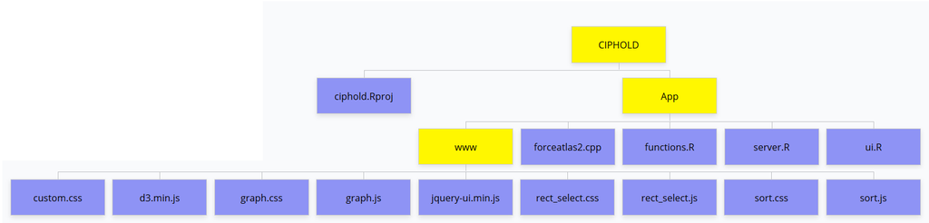

CIPHOLD is the main folder, containing:

- ciphold.Rproj, a file allowing the user to directly open R/RStudio with the working directory direcly set up to this folder, it is indeed also useful for further development.
- App, a directory containing all the components used to run the shiny application (other than the required elements from the “Requirements section”)

In App you have:

- server.R, the file containing all R code executed server-side of the shiny application. This is where you will code new interactions, functions and such. The new code is commented.
- ui.R, the R file containing the R code for the shiny interface. This is where you can add your widgets to the interface (see [shiny documentation](https://www.rstudio.com/) for more information). The new code is commented.
- functions.R, the R file containing all functions needed to run the application. All the new or modified functions are commented in the file, at the beggining of it. The second part is the functions taken as is, for them we invite you to read the original [SCAFFoLD documentation](https://github.com/nolanlab/scaffold).
- forceatlas2.cpp, the C++ code needed to create the force-directed maps, it remains untouched from the original SCAFFoLD.
- www, the folder containing all the css and javascript needed to run the application. Inside, only custom.css is new. It allows to modify some cosmetics that where not great in the original package and organise the new elements, especially server-side generated widgets.

# Project issues

Except for the problems discussed in the User Manual, we actually have a hard time packaging CIPHOLD. In fact, the packaging works but a problem with the C++ files produces a stack overflow when running the analysis. We will try again to package it for the next versions, using the new 3.5 R version.

# Contact

You can contact *Calvin Matteoli* the developer via e-mail at calvin.matteoli@gmail.com, stating “**[CIPHOLD]**” in the subject of your message.